# Tutorial: mlergm

Jonathan Stewart

2025-05-22

## Introduction

The R package `mlergm`, appropriately named “Multilevel Exponential-Family Random Graph Models,” aims to provide a convenient platform for estimating exponential-family random graph models (ERGMs) with multilevel structure. Presently, the beta release of the package supports estimation of ERGMs with non-overlapping block structure and local dependence (see the work of Schweinberger & Handcock (JRSS-B, 2015)), with plans to expand the coverage to overlapping block structure with local dependence and to structures with multiple levels and higher-order interactions in future updates.

The syntax of `mlergm` aims to mirror other network package interfaces, namely that of the `ergm` framework, to provide as small a learning curve as possible to users already acquainted with the `ergm` and `network` package framework. In the following sections, we aim to highlight how to use `mlergm` and some of the key features.

Before we proceed into demonstrating how to use `mlergm` and the functionality it has for multilevel networks analysis, we first review background on multilevel networks, as well as the main statistical model the package contains at present.

#### Brief background on multilevel networks

Multilevel networks come in many different forms, and we point readers to the introductory chapter written by Snijders in the monograph “Multilevel network analysis for the social sciences: theory, methods and applications” (Lazega & Snijders, Eds., 2016).

In the simplest form, a multilevel network has a set of nodes $\mathcal{N}$ (e.g., persons, brain regions, research articles) partitioned into $K$ blocks $\mathcal{A}_{1}, \ldots, \mathcal{A}_{K} \subseteq \mathcal{N}$ (e.g., departments within a university, individual patient brains, research journals), and a set of edges $\mathcal{E}$ which represent interactions, relationships, or connections between nodes (e.g., advice seeking, functional connectivity, citation). Network data are typically represented by an adjacency matrix $\boldsymbol{X}$, where in the case of a binary, undirected network, $X_{i,j} = 1$ if $\{i,j\} \in \mathcal{E}$, and $X_{i,j} = 0$ otherwise. The within-block subgraphs are denoted by $\boldsymbol{X}_{\mathcal{A}_k, \, \mathcal{A}_k}$ ($k = 1 , \ldots, K$) and the between-block subgraphare denoted by $\boldsymbol{X}_{\mathcal{A}_k, \, \mathcal{A}_l}$ ($1 \leq k < l \leq K$).

In practice, researchers are usually interested in super-population inference, where a network $X$, define on a finite population of nodes $\mathcal{N}$, is assumed to have been generated from a distribution $\mathbb{P}_{\mathcal{N}, \, \boldsymbol{\theta}}$, and the goal is to estimate $\boldsymbol{\theta}$ in order to learn about mechanisms driving edge formation.

Past procedures have taken to estimating models for such network data by

1. Estimating an ERGM with no additional structure.
2. Estimating individual ERGMs for each block subgraph.

Both of these approaches fail to take into account the natural structure of networks with block structure. The first is unable to adaptively model differences in within- and between-block edge formations, while the second may overfit to the data by estimating separate parameters for each within-block subgraph, and does not use the additional structure to help estimate a general model.

In `mlergm`, we estimate statistical models for networks $X$ of the form
$$\begin{aligned}
\mathbb{P}_{\mathcal{N}, \, \boldsymbol{\theta}, \,
\boldsymbol{\beta}}\left(\boldsymbol{X} = \boldsymbol{x}\right)
\;\;&= \;\; \prod_{k=1}^{K} \, \mathbb{P}_{\mathcal{A}_k, \,
\boldsymbol{\theta}} \left( \boldsymbol{X}_{\mathcal{A}_k, \,
\mathcal{A}_k} = \boldsymbol{x}_{\mathcal{A}_k, \,
\mathcal{A}_k}\right) \; \prod_{l \neq k}^{K}
\mathbb{P}_{\{\mathcal{A}_k, \, \mathcal{A}_l\}, \,
\beta}\left(\boldsymbol{X}_{\mathcal{A}_k, \, \mathcal{A}_l} =
\boldsymbol{x}_{\mathcal{A}_k, \, \mathcal{A}_l}\right),
\end{aligned}$$
where
$$\begin{align}
\mathbb{P}_{\{\mathcal{A}_k, \, \mathcal{A}_l\}, \,
\boldsymbol{\beta}}\left(\boldsymbol{X}_{\mathcal{A}_k, \,
\mathcal{A}_l} = \boldsymbol{x}_{\mathcal{A}_k, \, \mathcal{A}_l}\right)
\;\;&= \;\; \prod_{i \in \mathcal{A}_k} \; \prod_{j \in
\mathcal{A}_l} \; \mathbb{P}_{\{i,\,j\}, \, \boldsymbol{\beta}}\left(
X_{i,\,j} = x_{i,\,j}\right).
\end{align}$$

The key model assumption is that the within-neighborood subgraphs $\boldsymbol{X}_{\mathcal{A}_k, \, \mathcal{A}_k}$ ($k = 1, \ldots, K$) are mutually independent and that the between-block edges do not depend on the within-block edges. Dependence within the model is local in that it is restricted to blocks. Note as well that the $\boldsymbol{\theta}$ vector governs the within-block edges while the $\boldsymbol{\beta}$ vector governs the between-block edges, and the two are assumed to be variation independent. For more details on the model assumptions, see Schweinberger & Handcock (JRSS-B, 2015).

R package `mlergm` aims to provide an easy-to-use framework and interface for estimating models of the above form. In the coming sections, we will show how to get started with `mlergm` and will attempt to highlight key functionality that will help network scientists analyze such network data.

## Getting started with `mlergm`

In order to get acquainted with `mlergm`, let us consider a simple example: a network with $K = 3$ blocks, each with $30$ unique nodes.

```r
# Load R package mlergm
library(mlergm)

# Networks can be created in the same was as other packages
net <- network.initialize(90, directed = FALSE)

# The difference with mlergm is that we also have a block membership structure
node_memb <- c(rep(1, 30), rep(2, 30), rep(3, 30))
```

A network (`net`) and a vector of block memberships (`node_memb`) is all we need to start working with `mlergm`. We note that `node_memb` does not need to be strictly numeric, as will be the case in later examples. For obtaining `network` objects from adjacency matrices, edgelists, or other data structure, we refer readers to the R package `network` which provides this functionality. We will assume that the network `net` is always a `network` object.

Currently, `net` is an empty graph, which is uninteresting. We will show how synethetic networks can be simulated from a specified model using the `simulate_mlnet` function.

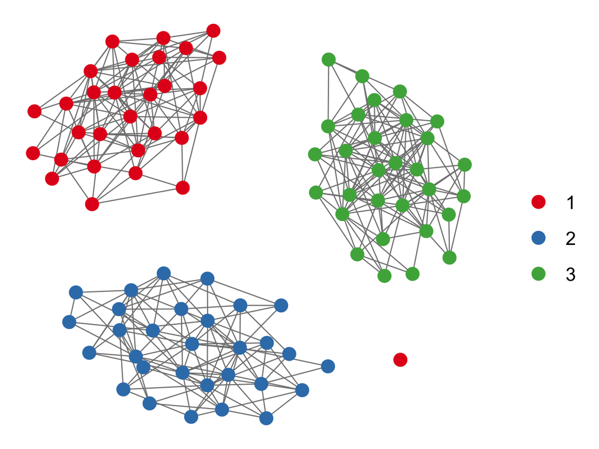

```r
# Simulate a network from the edge + gwesp model
net <- simulate_mlnet(form = net ~ edges + gwesp,
                      node_memb = node_memb,
                      seed = 123,
                      theta = c(-3, 1, .5))
plot(net)
```

The function `simulate_mlnet` returns a network which is both of class `mlnet` and `network`, and the `mlergm` package contains plotting methods for `mlnet` class networks, which allow for easy plotting of network data with block structure.

For real network data with block memberships, the network data can be converted to an `mlnet` class using the `mlnet` function.

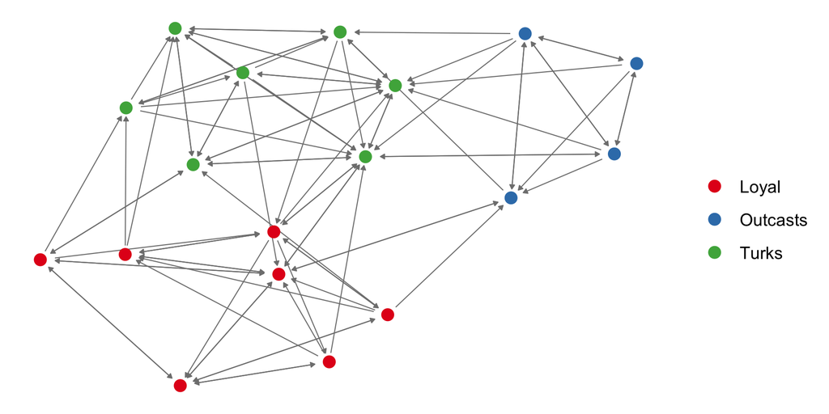

```r
# Let us use the sampson data set as an example
data(sampson)
sampson_net <- mlnet(network = samplike,
                     node_memb = get.vertex.attribute(samplike, "group"))
plot(sampson_net, arrow.size = 2.5, arrow.gap = 0.025)
```

The plotting functions of `mlergm` use the `GGally` package which extends the plotting capabilities of `ggplot2`. Specifically, the `mlnet` plotting method is a wrapper for the `ggnet2` function and can take most of the same plot parameters.

Estimation of specific models can be carried out via the `mlergm` function.

```r
# Estimate the edge + gwesp model for the simulated network
model_est <- mlergm(net ~ edges + gwesp, verbose = 0, seed = 123)
```

We can then view the results by calling the `summary` function, which has a method for `mlergm` objects.

```r
summary(model_est)
```

```
#>
#> ============================ Summary of model fit ============================
#>
#> Formula:  net ~ edges + gwesp(fixed = FALSE)
#>
#> Number of blocks:  3
#>
#> Quantiles of block sizes:
#>   0%  25%  50%  75% 100%
#>   30   30   30   30   30
#>
#>
#> Monte Carlo MLE Results:
#>
#> Within-block model terms:
#>                        Estimate   Std. Error    p-value    Sig.
#> edges                   -3.7690     0.4499      <0.00001
#> gwesp                    1.4700     0.3797       0.00011    ***
#> gwesp.decay              0.4360     0.1014       0.00002    ***
#> -----------------------------------------------------------------
#> Between block MLE does not exist.
#>
#> Sig. codes:  0 '***' 0.001 '**' 0.01 '*' 0.05 '.' 0.1 ' ' 1
#>
#> BIC:  1449.904
#> * Note: BIC is based on the within-block model
```

The `summary` function has a method for estimated objects of class `mlergm`, which has the following information:

1. The model formula estimated.
2. Some basic summary information on the block structure.
3. The Monte Carlo MLE estimates for each of the parameters.
4. Significance codes and p-values for each estimate, as well as estimates of the standard error.
5. BIC for the within-block model.

Note that when we simulated this network, we did not specify an edge parameter for the between-block edges. As such, the output of the `summary` function also is telling us that the between block MLE does not exist, because the number of between-block edges is precisely zero. Presently, `mlergm` attempts to estimate an edge coefficient when the number of between block edges is not extreme.

We can evaluate goodness-of-fit of a fitted model of class `mlergm` by calling the `gof` method:

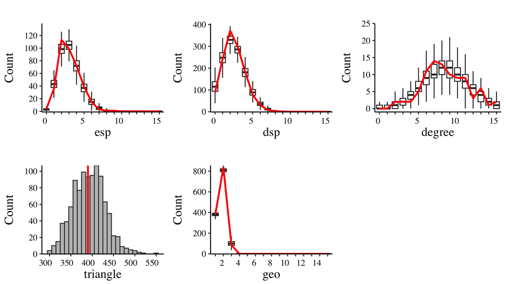

```r
# We can call the gof.mlergm method directly by calling 'gof' on an object of class 'mlergm'
gof_res <- gof(model_est)
plot(gof_res, cutoff = 15, pretty_x = TRUE)
```

The plot method argument `cutoff` specifies the maximum range to plot for the boxplots, and the argument `pretty_x` is a logical argument which indicates whether the `pretty` function should be used to decide the x-axis breaks for the boxplot, which can be helpful when the range is large.

## Exploring the estimation function `mlergm`

The function `mlergm` has a number of different options. Firstly, the function is capable of doing two different parameterizations:

1. ‘standard’: This parameterization option uses the parameter vector $\boldsymbol{\theta}$ without modification.
2. ‘offset’: When this parameterization is used, the parameter vector $\boldsymbol{\theta}$ will feature the size-dependent offsets of Krivitsky et. al (Statistical Methodology, 2011) for the edge term and, if the network is directed, the size-dependent offset of Krivitsky & Kolaczyk (Satatistical Science, 2015) for the mutual edge term as well (when the mutual edge term is included in the model):
   $$\begin{equation}
   \eta_{k,\text{edge}}(\boldsymbol{\theta}) \;\;\;=\;\;
   \boldsymbol{\theta}_{\text{edge}} \,\;\;\;\;-\;\; \log \,
   |\mathcal{A}_k|
   \end{equation}$$
   $$\begin{equation}
   \eta_{k, \text{mutual}}(\boldsymbol{\theta}) \;\;=\;\;
   \boldsymbol{\theta}_{\text{mutual}} \;\;+\;\; \log \,
   |\mathcal{A}_k|,
   \end{equation}$$
   where $\eta_{k,\text{edge}}(\boldsymbol{\theta})$ is the natural parameter for the edge term in block $k$ and $\eta_{k, \text{mutual}}(\boldsymbol{\theta})$ is the natural parameter for the mutual term in block $k$.

This can be done by setting `parameterization == "offset"` in the `mlergm` call:

```r
offset_est <- mlergm(sampson_net ~ edges + mutual,
                     seed = 123,
                     parameterization = "offset")
```

We can inspect the results, again, using the `summary` function.

```r
summary(offset_est)
```

```
#>
#> ============================ Summary of model fit ============================
#>
#> Formula:  sampson_net ~ edges + mutual
#> Parameterization set to 'offset'
#>
#> Number of blocks:  3
#>
#> Quantiles of block sizes:
#>   0%  25%  50%  75% 100%
#>  4.0  5.5  7.0  7.0  7.0
#>
#>
#> Monte Carlo MLE Results:
#>     Within-block edge parameter    =  edge parameter estimate   - log(block size)
#>     Within-block mutual parameter  =  mutual parameter estimate + log(block size)
#>     -------------------------------------------------------------------------------------------
#>     Between-block edge parameter   =  between-block edge parameter estimate * log(network size)
#>
#> Within-block model terms:
#>                        Estimate   Std. Error    p-value    Sig.
#> edges                    1.9460     0.4213      <0.00001
#> mutual                  -0.9504     0.6252       0.12848
#> -----------------------------------------------------------------
#> Between edges     -2.0010     0.2131      <0.00001
#>
#>
#> Sig. codes:  0 '***' 0.001 '**' 0.01 '*' 0.05 '.' 0.1 ' ' 1
#>
#> BIC:  129.613
#> * Note: BIC is based on the within-block model
```

The `summary` output includes additional information when `parameterization == "offset"` notably including a reminder about the edge parameters.

The `mlergm` function can also take an initial parameter value through the argument `theta_init`, which can be useful when starting points are challenging to find or a procedure did not run to convergence. Lastly, the argument `verbose` has three levels:

1. `verbose = 0`: (default) no output is printed to the console.
2. `verbose = 1`: minimal output is printed to the console informing which steps of the procedure the estimation method is in.
3. `verbose = 2`: maximal output is printed to the console.

## Options for estimation and simulation

The `set_options` function is used in all code which involves estimation or simulation, which includes `mlergm`, `simulate_mlnet`, and the method `gof.mlergm`. It is included as an argument `options = set_options()`. A description of all possible functionality can be seen by using `help(set_options)`, however, here we highlight a few key parameters.

#### Simulation parameters

For simulation (both in simulating networks and for MCMC estimation), the `burnin`, `interval`, and `sample_size` arguments are relevant and can be specified through set_options:

```r
mlergm(net ~ edges + gwesp,
       options = set_options(burnin = 5000, interval = 500, sample_size = 2500))
```

One of the primary benefits of using locally dependent block models is that simulation and computations of the blocks can be done independently and in parallel. The `set_options` function can control the number of cores used for computation and simulation. The default is `number_cores = detectCores(all.tests = FALSE, logical = TRUE) - 1`, which will typically be one less than the maximum number of available cores.

```r
mlergm(net ~ edges + gwesp,
       options = set_options(number_cores = 3))
```

The `number_cores` argument is relevant for both simulation and estimation procedures.

#### Estimation parameters

For estimation procedures, the Fisher Scoring method of Hunter & Handcock (JCGS, 2006) is used. Netwon-based optimization methods can be sensitive to the step length used. These options can be changed by using the `step_len` argument. Additionally, there is an option to use a naive adaptive step length by setting `adaptive_step_len == TRUE`.

```r
# Adjust the step length manually
mlergm(net ~ edges + gwesp,
       options = set_options(step_len = 0.25))

# Use the naive adaptive step length
mlergm(net ~ edges + gwesp,
       options = set_options(adaptive_step_len == TRUE))
```

The adaptive step length uses step lengths equal to the reciprocal of the $L_2$ norm of the increment, i.e.,
$$\begin{equation}
\text{Step length} \;\;\;=\;\;\;
\frac{1}{||\,\text{Increment}\,||_2}
\end{equation}$$
The outcome is a step length which automatically adjusts depending on the size of the increment. When the updates to the parameter vector $\boldsymbol{\theta}$ are small, the step length will be greater, encouraging faster convergence when near the solution. When the changes are larger, then the step length will be smaller as a result, and will more conservatively iterate towards the solution, which can help improve convergence, especially for estimation of curved ERGMs.

The number of maximum iterations performed can be adjusted for both the MCMLE procedure and the Newton-based Fisher Scoring algorithm, as well as the tolerance for the Fisher scoring convergence.

```r
mlergm(net ~ edges + gwesp,
       options = set_options(MCMLE_max_iter = 10,
                             NR_max_iter = 100,
                             NR_tol = 1e-4))
```

The other options can be viewed in `help(set_options)`.